# Final_R_Simulations_DivyaP

# sample(x,size,replace)

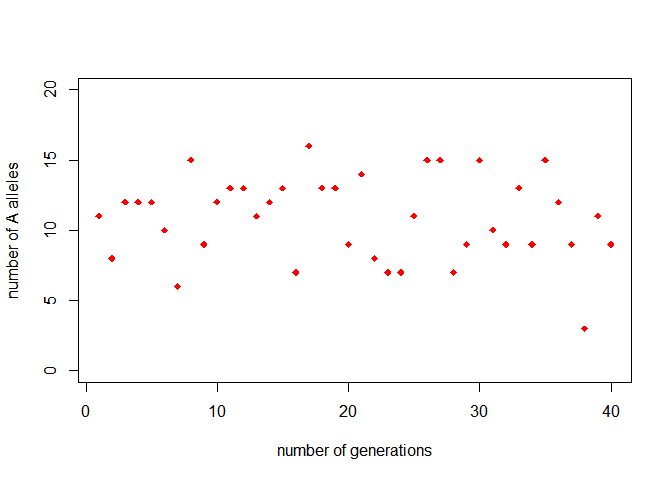

```r
allele_freq <- function(A, alleles, gen) {
  allele <- sample(c("a", "A"), size = 40, replace = TRUE, prob = c(A, 1-A))

plot(1,0, type = "n",  xlim=c(1,40), ylim=c(0,20), xlab="number of generations", ylab="number of A alleles")

for(i in 1:gen) {
  alleles <- sample(allele, 40, replace = TRUE)

points(i, length(alleles[alleles=="A"]), pch = 18, col = "red")
}
}

allele_freq(0.7,14,40)
```

# OR

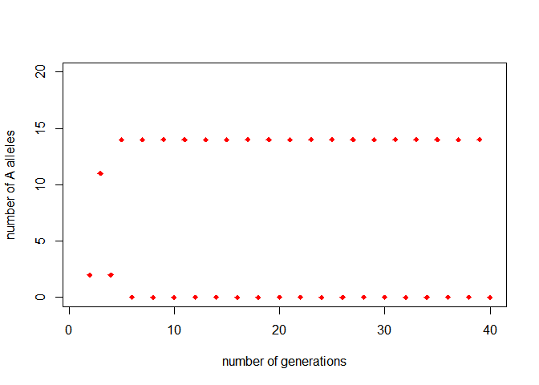

```r
allele_freq <- function(A, alle, gen) {
  allele_freq <- rep(NA,gen) #vector to store allele frequencies
  allele_freq[1] <- A

  allele_counts <- sample(c("a", "A"), size = alle, replace = TRUE, prob = c(A, 1-A))
plot(1,0, type = "n",  xlim=c(1,40), ylim=c(0,20), xlab="number of generations", ylab="number of A alleles")

for(i in 2:gen) {
  allele_counts <- sample(c("a","A"), size =  alle, replace = TRUE, prob = c(allele_freq[i-1],(1-allele_freq[i-1])))

  allele_freq[i] <- length(allele_counts[allele_counts=="A"])/length(allele_counts)

points(i, length(allele_counts[allele_counts=="A"]), pch = 18, col = "red")
}
}
allele_freq(0.7,14,40)
```

4 - Repeating your stochastic simulation. Now that you have a working simulator of genetic drift, you want to use it to assess how likely it is for the allele to be lost (p = 0) after a certain number of generations of drift (we will use 100 generations, but your function should be flexible). Using your function (you can modify it if you need to), perform a simulation 1000 times each with starting allele frequencies of p = f(A) of 0.5, 0.25 and 0.1, with 200 diploid individuals in the population each generation. Have your function record the proportion (out of 1000) of simulated runs that the A allele is lost from the population (p = 0).

```r
set.seed(720)
allele_freq <- function(A, alle, gen) {
  allele_freq <- rep(NA,gen) #Vecotr to store allele frequencies
  allele_freq[1] <- A

  allele_counts <- sample(c("a", "A"), size = alle, replace = TRUE, prob = c(A, 1-A))
#plot(1,0, type = "n",  xlim=c(1,40), ylim=c(0,20), xlab="number of generations", ylab="number of A alleles")

for(i in 2:gen) {
  allele_counts <- sample(c("a","A"), size =  alle, replace = TRUE, prob = c(allele_freq[i-1],(1-allele_freq[i-1])))

  allele_freq[i] <- length(allele_counts[allele_counts=="A"])/length(allele_counts)

#points(i, length(allele_counts[allele_counts=="A"]), pch = 18, col = "red")
}
  return(allele_freq[length(allele_freq)])
}

#Run for 100 generations & 200 individuals with different allele frequencies, one easy way to know is using replicate function.

mean(replicate(1000, allele_freq(0.5,200,100)) == 0)
```

```
## [1] 0.075
```

```r
mean(replicate(1000, allele_freq(0.25,200,100)) == 0)
```

```
## [1] 0.007
```

```r
mean(replicate(1000, allele_freq(0.1,200,100)) == 0)
```

```
## [1] 0
```

5 - Write some code that allows you to plot the allele trajectories for drift for 100 of the simulations starting at p = 0.5. hint: I showed you an example of how to draw multiple lines with a single function last week. . . It could look something like this.

```r
allele_freq <- function(A, alle, gen) {
  allele_freq <- rep(NA,gen)
  allele_freq[1] <- A

  allele_counts <- sample(c("a", "A"), size = alle, replace = TRUE, prob = c(A, 1-A))
#plot(1,0, type = "n",  xlim=c(1,40), ylim=c(0,20), xlab="number of generations", ylab="number of A alleles")

for(i in 2:gen) {
  allele_counts <- sample(c("a","A"), size =  alle, replace = TRUE, prob = c(allele_freq[i-1],(1-allele_freq[i-1]))) #freq of allels change

  allele_freq[i] <- length(allele_counts[allele_counts=="A"])/length(allele_counts)

  }
return(allele_freq)
}
allele_freq(0.5,200,100)
```

```
##   [1] 0.500 0.480 0.550 0.450 0.580 0.370 0.620 0.370 0.580 0.395 0.585
##  [12] 0.380 0.700 0.315 0.690 0.295 0.670 0.280 0.745 0.235 0.815 0.190
##  [23] 0.795 0.225 0.810 0.165 0.825 0.170 0.810 0.200 0.790 0.185 0.840
##  [34] 0.165 0.795 0.205 0.810 0.135 0.850 0.160 0.865 0.130 0.870 0.160
##  [45] 0.820 0.170 0.840 0.145 0.835 0.130 0.830 0.180 0.805 0.205 0.780
##  [56] 0.215 0.745 0.285 0.725 0.335 0.665 0.270 0.710 0.260 0.770 0.205
##  [67] 0.780 0.230 0.725 0.280 0.705 0.265 0.745 0.225 0.760 0.220 0.775
##  [78] 0.205 0.810 0.200 0.760 0.260 0.720 0.285 0.695 0.315 0.685 0.305
##  [89] 0.640 0.320 0.705 0.310 0.715 0.295 0.730 0.260 0.805 0.280 0.750
## [100] 0.270
```

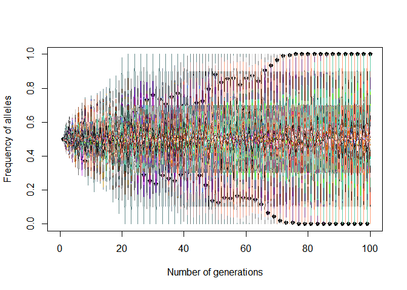

```r
ran_colors <- sample(colors(), size = 100)  #random colors

p <- allele_freq(A = 0.5, alle = 200,gen = 100)
generations <- 1:length(p) #same as did in 2nd QA
plot(p ~ generations, lty = 1, lwd = 3, pch = 20,
     ylab = "Frequency of alleles",
     xlab = "Number of generations",
     ylim= c(0,1), xlim= c(0,100))

for(i in 1:100){
  lines(allele_freq(A = 0.5, alle = 200,gen = 100), type = "l", col= sample(ran_colors, rep = F, size = 1)) #replac is False,so one color is not replaced with other
}
```

6. A simple power analysis. One common use for stochastic simulations is to evaluate the statistical power of a particular method or model given some known parameters such as effect size (like the slope of the regression line), sample size, and residual standard error (the uncertainty in your estimator). While I kind of detest teaching anything with p-values (it is not a great way of evaluating statistical models) we will use them for this exercise. We saw in class how to simulate data for the relationship between y and x and plot the regression fits (best fit lines) for the simulated data. You are going to use that same approach to determine how often you observe a “significant” p-value (p < 0.05) under some different scenarios. In class we did something approximately like this (with a few changes)

# Given function

```r
x <- seq(from =1, to = 10, length.out = 20) # length.out is how many observations we will have
a <- 0.5 # intercept
b <- 0.1 # slope
y_deterministic <- a + b*x
y_simulated <- rnorm(length(x), mean = y_deterministic, sd = 2)
mod_sim <- lm(y_simulated ~ x)
p_val_slope <- summary(mod_sim)$coef[2,4] # extracts the p-value
p_val_slope
```

```
## [1] 0.8249865
```

# reset the formula

```r
diff_values <- function(a = int, b = slope, samplesize, rse) {
  x <- seq(from =1, to = 10, length.out = samplesize)
y_deterministic <- a + b*x
y_simulated <- rnorm(length(x), mean = y_deterministic, sd = rse)
mod_sim <- lm(y_simulated ~ x)
p_val_slope <- summary(mod_sim)$coef[2,4] # extracts the p-value
return(p_val_slope)
}
diff_values(0.5,0.1,20,2)
```

```
## [1] 0.3659154
```

# Run 1000 times and generate histogram

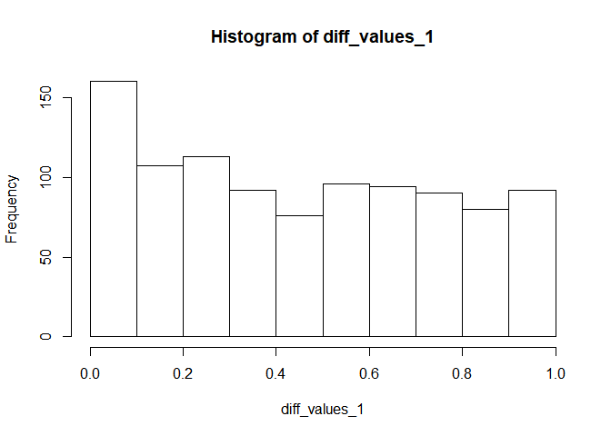

```r
set.seed(720)
diff_values_1 <- replicate(1000, diff_values(0.5, 0.1, 20, 2))

hist(diff_values_1)
```

# Check the p value

```r
p_value <- (table(diff_values_1 <0.05)/length(diff_values_1)) [["TRUE"]]
p_value #The p-value is more than 0.05
```

```
## [1] 0.107
```

# Redo this by giving slope 0

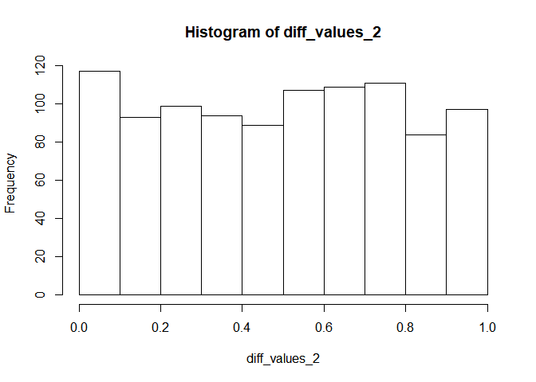

```r
set.seed(720)
diff_values_2 <- replicate(1000, diff_values(0.5, 0, 20, 2))
hist(diff_values_2)
```

# Check the p value

```r
p_value_1 <- (table(diff_values_2<0.05)/length(diff_values_2)) [["TRUE"]]
p_value_1
```

```
## [1] 0.061
```

Based on this (y_deterministic <- a + b*x) If the the slope(b) is set zero and the intercept(a) 0.5, the output will be a straight line, Thats because when the slope is zero and if it interacts with x that also becomes zero. then y_deterministic value becomes constant showing no significance.

. Finally, using either a for loop or an Rish method (i.e. one of the apply family of functions) try a grid of sample sizes from 10 to 100 by 5 (i.e. 10, 15, 20. . . ., 95, 100) with the slope being fixed at 0.1, intercept = 0.5 and residual standard error as 1.5. At each different sample size, run the simulation 100 times and report the frequency at which the p value is less than 0.05. What pattern do you observe. Plotting the proportion of p-values less than 0.05 on the Y axis VS sample size (X axis) may be very helpful 3

# Used apply function (sapply)

```r
sample_grid <- seq(10,100, 5) #by 5 for sample size
fixed_sample_grid <- function(size, times = 100) {
  final_values <- replicate(100, diff_values(0.5, 0.1, size, 1.5))

  #for (i in 1:100) {
    fin_values <- diff_values(0.5,0.1,size,1.5)
  #}
  less_values <- (table(final_values <0.05)/length(final_values)) [["TRUE"]]
}
plot_x <- sapply(sample_grid, fixed_sample_grid, times = 100) #p value less than 0.05
head(plot_x)
```

```
## [1] 0.03 0.09 0.12 0.13 0.12 0.23
```

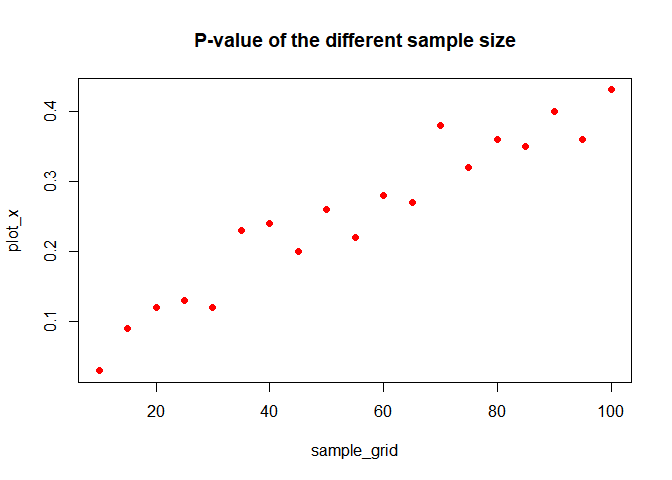

```r
plot(x = sample_grid, y = plot_x, main = "P-value of the different sample size", pch = 16, col = "red")
```